# Analysis

# Import Golder(+alesina+CLEA)

This file has been merged through STATA “legnewDOFILE.do” dofile, the resulting filo of which is available at “https://github.com/pgrau7/ES-0/blob/master/Creating%20the%20final%20dataset/LegisCLEAN.dta?raw=true” as a .dta file.

```r
data <- read_dta("https://github.com/pgrau7/ES-0/blob/master/Creating%20the%20final%20dataset/LegisCLEAN.dta?raw=true")
```

# Regressions replication

## Descriptive Statistics

### Testing Ethnic Fractionalization

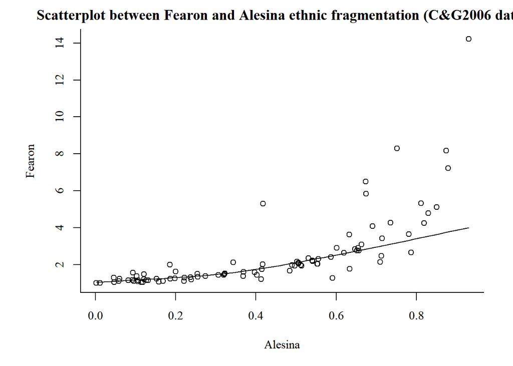

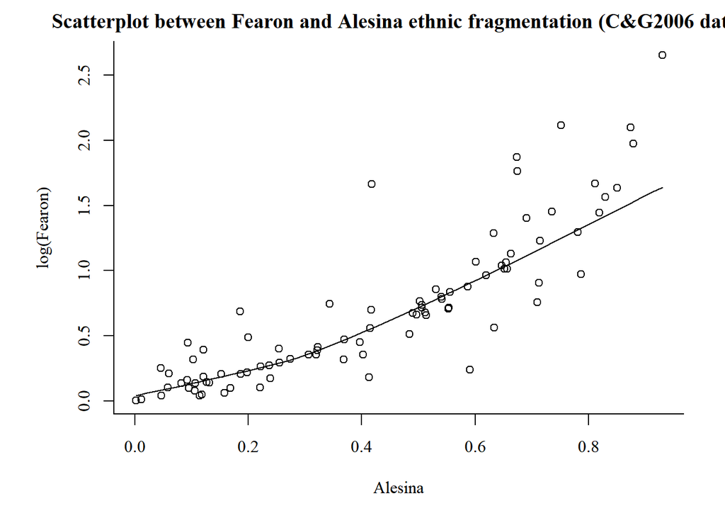

```
## [1] 0.6912115
```

```
## [1] 0.8516942
```

The correlation between Alesina and Fearon in the data used is about 70%, which the same found by Alesina[^1]

## Cross sectional analysis

In the chunk below I replicate Golder’s cross sectional analyses. In the first two models (CS1 and CS1O) ethnic fractionalization is measured with Fearon (2003) data -provided by Clark & Golder (2006), whereas in the two next models (CS1AL, CS1OAL) Alesina is used.

```r
CS1 <- lm(enep1~eneg+logmag+uppertier+enpres+proximity1+logmag*eneg+uppertier*eneg+proximity1*enpres, data=subset(data, nineties==1))

CS1O <- lm(enep1~eneg+logmag+uppertier+enpres+proximity1+logmag*eneg+uppertier*eneg+proximity1*enpres, data=subset(data, nineties==1 & old==1))

CS1AL <- lm(enep1~EthAl+logmag+uppertier+enpres+proximity1+logmag*EthAl+uppertier*EthAl+proximity1*enpres, data=subset(data, nineties==1))

CS1OAL <- lm(enep1~EthAl+logmag+uppertier+enpres+proximity1+logmag*EthAl+uppertier*EthAl+proximity1*enpres, data=subset(data, nineties==1 & old==1))

#stargazer::stargazer(CS1, CS1AL, CS1O, CS1OAL, type="text", dep.var.caption  = "Cross-sectional analysis replication", column.labels = c("1990s Whole Sample", "1990s Whole Sample","1990s Established Democracies", "1990s Established Democracies"))
```

```r
stargazer::stargazer(CS1, CS1AL, CS1O, CS1OAL, type="html", dep.var.caption  = "Clark&Golder 2006 analysis replication: Fearon vs. Alesina",  column.labels = c("1990s Whole Sample (Fearon)","1990s Whole Sample (Alesina)", "1990s Established Democracies (Fearon)", "1990s Established Democracies (Alesina)"))
```

|  | Clark&Golder 2006 analysis replication: Fearon vs. Alesina |  |  |  |
| --- | --- | --- | --- | --- |
|  | enep1 |  |  |  |
|  | 1990s Whole Sample (Fearon) | 1990s Whole Sample (Alesina) | 1990s Established Democracies (Fearon) | 1990s Established Democracies (Alesina) |
|  | (1) | (2) | (3) | (4) |
| eneg | 0.061 |  | -0.703 |  |
|  | (0.371) |  | (0.677) |  |
| EthAl |  | 1.528 |  | -0.428 |
|  |  | (1.401) |  | (1.241) |
| logmag | 0.509 | 0.534 | -0.610 | 0.215 |
|  | (0.443) | (0.335) | (0.589) | (0.268) |
| uppertier | 0.011 | 0.045* | -0.022 | 0.014 |
|  | (0.025) | (0.025) | (0.058) | (0.023) |
| enpres | 0.364 | 0.501** | 0.067 | 0.221 |
|  | (0.257) | (0.231) | (0.216) | (0.194) |
| proximity1 | -4.194*** | -3.891*** | -4.950*** | -4.482*** |
|  | (1.258) | (1.083) | (1.239) | (1.082) |
| eneg:logmag | -0.095 |  | 0.625* |  |
|  | (0.168) |  | (0.340) |  |
| eneg:uppertier | -0.005 |  | 0.013 |  |
|  | (0.010) |  | (0.039) |  |
| EthAl:logmag |  | -0.412 |  | 1.308* |
|  |  | (0.671) |  | (0.777) |
| EthAl:uppertier |  | -0.107* |  | -0.001 |
|  |  | (0.057) |  | (0.074) |
| enpres:proximity1 | 0.985** | 0.887** | 1.423*** | 1.201*** |
|  | (0.456) | (0.418) | (0.435) | (0.386) |
| Constant | 4.075*** | 2.946*** | 5.152*** | 3.391*** |
|  | (0.954) | (0.701) | (1.325) | (0.550) |
| Observations | 62 | 78 | 39 | 51 |
| R<sup>2</sup> | 0.288 | 0.312 | 0.482 | 0.496 |
| Adjusted R<sup>2</sup> | 0.181 | 0.232 | 0.344 | 0.400 |
| Residual Std. Error | 2.081 (df = 53) | 1.927 (df = 69) | 1.411 (df = 30) | 1.322 (df = 42) |
| F Statistic | 2.683** (df = 8; 53) | 3.903*** (df = 8; 69) | 3.494*** (df = 8; 30) | 5.158*** (df = 8; 42) |
| *Note:* | p<0.1; p<0.05; p<0.01 |  |  |  |

We have succeded in reproducing Clark & Golder (2006) models. From these results, Alesina’s measure seems to fit well the models:

- It has a higher number of observations in the dataset
- It presents a higher R<sup>2</sup>
- Results aren’t qualitetively different.

### Are assumptions met?

We should, though, see if the models fit with the assumptions of OLS. Let’s work with CS1AL -which had the biggest number of observations.

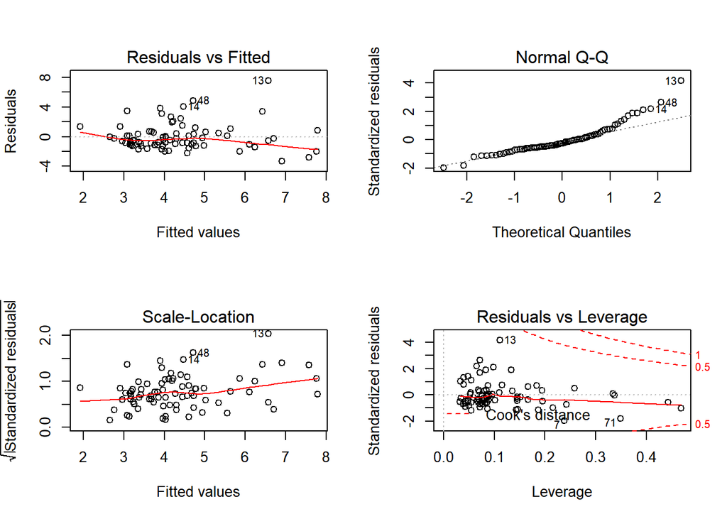

```r
par(mfrow = c(2, 2))
plot(CS1AL)+theme_bw()
```

```r
olsrr::ols_test_normality(CS1AL)
```

```
## -----------------------------------------------
##        Test             Statistic       pvalue
## -----------------------------------------------
## Shapiro-Wilk              0.8857         0.0000
## Kolmogorov-Smirnov        0.1476         0.0602
## Cramer-von Mises          8.2404         0.0000
## Anderson-Darling          2.7074         0.0000
## -----------------------------------------------
```

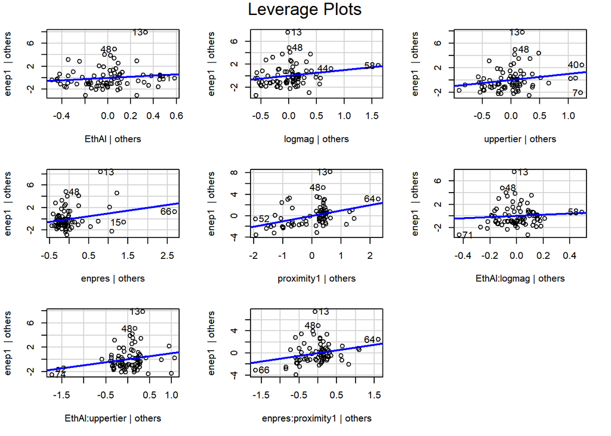

```r
leveragePlots(CS1AL)
```

```r
bptest(CS1AL)
```

```
##
##  studentized Breusch-Pagan test
##
## data:  CS1AL
## BP = 13.936, df = 8, p-value = 0.08344
```

- Multicollinearity: No problem (all less than 10, higher than 5 if interaction).

```r
vif(CS1AL)
```

```
##             EthAl            logmag         uppertier            enpres
##          2.406415          4.069856          4.119967          3.350340
##        proximity1      EthAl:logmag   EthAl:uppertier enpres:proximity1
##          4.806950          5.081636          3.944312          7.884060
```

## Pooled model

In order to have a more extensive sample, CG2006 included all observations of the dataset in the analysis. As it is panel data with different observations per each country (in different dates), an OLS model would have heteroskedasticity, which can be addressed by treating panel data as such: - Breusch-Pagan test: BP = 49.255, df = 8, p-value = 5.682e-08

```r
WS <- lm(log(enep1)~eneg+logmag+uppertier+enpres+proximity1+logmag_eneg+uppertier_eneg+proximity1_enpres, data=data)
bptest(WS)
```

```
##
##  studentized Breusch-Pagan test
##
## data:  WS
## BP = 49.255, df = 8, p-value = 5.682e-08
```

```r
data1 <- data
data <- subset(data1, year!=".")
```

Models:

- poolWS: Pooled model. Whole sample. C&G(2006) model.
- poolWSAL: Pooled model. Whole sample. Alesina Ethnic Fractionalization (EthAl). C&G(2006) model.
- poolED: Pooled model. Established democracies. C&G(2006) model.
- poolEDAL: Pooled model. Established democracies and Alesina Ethnic Fractionalization (EthAl). C&G(2006) model.
- EDAL: LM model. Established democracies and Alesina Ethnic Fractionalization (EthAl). C&G(2006) model. Heteroskedastic.

In the table below, robust s.e. are clustered by country through a HC1 covariance matrix.

```r
poolWS <- plm(enep1~eneg+logmag+uppertier+enpres+proximity1+eneg*logmag+uppertier*eneg+proximity1*enpres, data=data, index=c("country"), model="pooling")
robust_seWS <- sqrt(diag(vcovHC(poolWS, type = "HC1")))

poolWSAL <- plm(enep1~EthAl+logmag+uppertier+enpres+proximity1+logmag*EthAl+uppertier*EthAl+proximity1*enpres, data=data, index=c("country"), model="pooling")
robust_seWSAL <- sqrt(diag(vcovHC(poolWSAL, type = "HC1")))

poolED <- plm(enep1~eneg+logmag+uppertier+enpres+proximity1+logmag*eneg+uppertier*eneg+proximity1*enpres, data=subset(data, old==1), index=c("country"), model="pooling")
robust_seED <- sqrt(diag(vcovHC(poolED, type = "HC1")))

poologED <- plm(enep1~log(eneg)+logmag+uppertier+enpres+proximity1+logmag*log(eneg)+uppertier*log(eneg)+proximity1*enpres, data=subset(data, old==1), index=c("country"), model="pooling")
robust_selogED <- sqrt(diag(vcovHC(poologED, type = "HC1")))

poolEDAL <- plm(enep1~EthAl+logmag+uppertier+enpres+proximity1+logmag*EthAl+uppertier*EthAl+proximity1*enpres, data=subset(data, old==1), index=c("country"), model="pooling")
robust_seEDAL <- sqrt(diag(vcovHC(poolEDAL, type = "HC1")))

EDAL <- lm(enep1~EthAl+logmag+uppertier+enpres+proximity1+logmag*EthAl+uppertier*EthAl+proximity1*enpres, data=subset(data, old==1))
```

|  | Clark&Golder 2006 pooled analysis replication |  |  |  |
| --- | --- | --- | --- | --- |
|  | enep1 |  |  |  |
|  | 1946 to 2000 ws pooled | 1946 to 2000 ws pooled(alesina) | 1946 to 2000 EDP | 1946 to 2000 EDP alesina |
|  | (1) | (2) | (3) | (4) |
| eneg | 0.195 |  | 0.116 |  |
|  | (0.129) |  | (0.143) |  |
| EthAl |  | 0.328 |  | -0.072 |
|  |  | (0.697) |  | (0.661) |
| logmag | 0.341* | 0.309*** | 0.089 | 0.274** |
|  | (0.194) | (0.120) | (0.228) | (0.113) |
| uppertier | 0.049*** | 0.034** | -0.054 | 0.013 |
|  | (0.015) | (0.015) | (0.033) | (0.016) |
| enpres | 0.348** | 0.458*** | 0.269* | 0.326** |
|  | (0.163) | (0.168) | (0.143) | (0.145) |
| proximity1 | -3.414*** | -3.188*** | -3.093*** | -2.904*** |
|  | (0.551) | (0.545) | (0.456) | (0.488) |
| eneg:logmag | 0.074 |  | 0.261 |  |
|  | (0.116) |  | (0.169) |  |
| eneg:uppertier | -0.016** |  | 0.058*** |  |
|  | (0.007) |  | (0.021) |  |
| EthAl:logmag |  | 0.496 |  | 0.963* |
|  |  | (0.424) |  | (0.502) |
| EthAl:uppertier |  | -0.050 |  | 0.045 |
|  |  | (0.048) |  | (0.068) |
| enpres:proximity1 | 0.800*** | 0.676*** | 0.683*** | 0.646*** |
|  | (0.229) | (0.216) | (0.227) | (0.211) |
| Constant | 2.775*** | 2.855*** | 2.874*** | 2.892*** |
|  | (0.331) | (0.249) | (0.336) | (0.236) |
| Observations | 549 | 653 | 481 | 579 |
| R<sup>2</sup> | 0.305 | 0.309 | 0.404 | 0.378 |
| Adjusted R<sup>2</sup> | 0.295 | 0.300 | 0.394 | 0.369 |
| F Statistic | 29.599*** (df = 8; 540) | 35.977*** (df = 8; 644) | 40.061*** (df = 8; 472) | 43.310*** (df = 8; 570) |
| *Note:* | p<0.1; p<0.05; p<0.01 |  |  |  |

Alesina has more values, we increase the df.

## Genuine models

Prior to adding variance, we will test the differences when using Fearon and Alesina in pooled models.

```r
stargazer::stargazer(poolED, poolEDAL, se=list(robust_seED, robust_seEDAL), type="html", column.labels = c("Alesina", "Fearon"))
```

[output not shown]

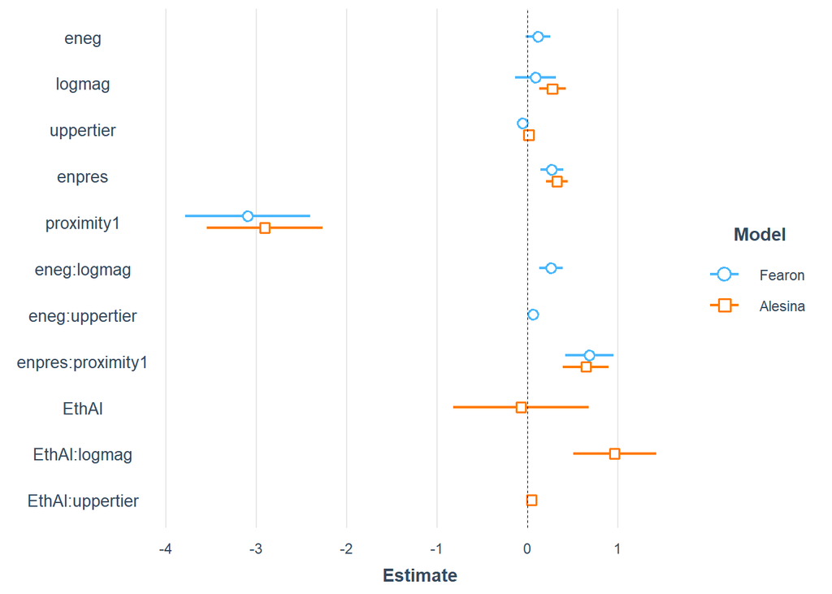

```r
jtools::plot_summs(poolED, poolEDAL, scale = TRUE, robust = list(robust_seED ,robust_seEDAL), model.names = c("Fearon", "Alesina"))
```

- poolEDAL: Pooled model with s.e. clustered by country. Established Democracies.
- poolEDAL1: Pooled model with s.e. clustered by country. Established Democracies whose value for variance is not missing.
- poolEDALv: Pooled model with s.e. clustered by country. Established Democracies whose value for variance is not missing. Variance as an additive variable.
- poolEDALvx: Pooled model with s.e. clustered by country. Established Democracies whose value for variance is not missing. Variance as a constitutional term of the interaction between variance and logmag.

```r
poolEDAL <- plm(enep1~EthAl+logmag+uppertier+enpres+proximity1+logmag*EthAl+uppertier*EthAl+proximity1*enpres, data=subset(data, old==1), index=c("country"), model="pooling")
robust_seEDAL <- sqrt(diag(vcovHC(poolEDAL, type = "HC1")))

poolEDAL1 <- plm(enep1~EthAl+logmag+uppertier+enpres+proximity1+logmag*EthAl+uppertier*EthAl+proximity1*enpres, data=subset(data, old==1&!is.na(data$varmag)), index=c("country"), model="pooling")
robust_seEDAL1 <- sqrt(diag(vcovHC(poolEDAL1, type = "HC1")))

lpoolEDAL1 <- plm(log(enep1)~EthAl+logmag+uppertier+enpres+proximity1+logmag*EthAl+uppertier*EthAl+proximity1*enpres, data=subset(data, old==1&!is.na(data$varmag)), index=c("country"), model="pooling")
robust_selEDAL1 <- sqrt(diag(vcovHC(lpoolEDAL1, type = "HC1")))

poolEDALv <- plm(enep1~EthAl+logmag+uppertier+enpres+proximity1+logmag*EthAl+uppertier*EthAl+proximity1*enpres+varmag, data=subset(data, old==1), index=c("country"), model="pooling")
robust_seEDALv <- sqrt(diag(vcovHC(poolEDALv, type = "HC1")))

lpoolEDALv <- plm(log(enep1)~EthAl+logmag+uppertier+enpres+proximity1+logmag*EthAl+uppertier*EthAl+proximity1*enpres+varmag, data=subset(data, old==1), index=c("country"), model="pooling")
robust_selEDALv <- sqrt(diag(vcovHC(lpoolEDALv, type = "HC1")))

poolEDALvx <- plm(enep1~EthAl+logmag+uppertier+enpres+proximity1+logmag*EthAl+uppertier*EthAl+proximity1*enpres+varmag+varmag*logmag, data=subset(data, old==1), index=c("country"), model="pooling")
robust_seEDALvx <- sqrt(diag(vcovHC(poolEDALvx, type = "HC1")))

poolEDALvxe <- plm(enep1~EthAl+logmag+uppertier+enpres+proximity1+logmag*EthAl+uppertier*EthAl+proximity1*enpres+varmag+varmag*logmag+varmag*EthAl, data=subset(data, old==1), index=c("country"), model="pooling")
robust_seEDALvxe <- sqrt(diag(vcovHC(poolEDALvxe, type = "HC1")))


lpoolEDALvx <- plm(log(enep1)~EthAl+logmag+uppertier+enpres+proximity1+logmag_ethal+uppertier_ethal+proximity1_enpres+varmag+varmag*logmag, data=subset(data, old==1), index=c("country"), model="pooling")
robust_selEDALvx <- sqrt(diag(vcovHC(lpoolEDALvx, type = "HC1")))
```

|  | Clark&Golder 2006 pooled analysis replication |  |  |  |
| --- | --- | --- | --- | --- |
|  | enep1 |  |  |  |
|  | 1946 to 2000 ED | 1946 to 2000 ED (reduced sample) | additive model | interactive model |
|  | (1) | (2) | (3) | (4) |
| EthAl | -0.072 | 0.134 | 0.113 | 0.096 |
|  | (0.661) | (0.550) | (0.559) | (0.558) |
| logmag | 0.274** | 0.293 | 0.203 | 0.203 |
|  | (0.113) | (0.248) | (0.262) | (0.267) |
| uppertier | 0.013 | 0.017** | 0.019*** | 0.021*** |
|  | (0.016) | (0.008) | (0.007) | (0.007) |
| enpres | 0.326** | 0.352* | 0.320 | 0.330 |
|  | (0.145) | (0.197) | (0.208) | (0.204) |
| proximity1 | -2.904*** | -1.695*** | -1.600*** | -1.696*** |
|  | (0.488) | (0.547) | (0.541) | (0.541) |
| varmag |  |  | 0.020 | 0.042* |
|  |  |  | (0.020) | (0.022) |
| EthAl:logmag | 0.963* | 0.461 | -0.304 | 0.031 |
|  | (0.502) | (0.535) | (0.946) | (0.974) |
| EthAl:uppertier | 0.045 | 0.002 | -0.019 | -0.039 |
|  | (0.068) | (0.045) | (0.037) | (0.037) |
| enpres:proximity1 | 0.646*** | 0.277 | 0.285 | 0.286 |
|  | (0.211) | (0.241) | (0.240) | (0.233) |
| logmag:varmag |  |  |  | -0.012 |
|  |  |  |  | (0.008) |
| Constant | 2.892*** | 2.747*** | 2.765*** | 2.766*** |
|  | (0.236) | (0.179) | (0.183) | (0.184) |
| Observations | 579 | 243 | 243 | 243 |
| R<sup>2</sup> | 0.378 | 0.284 | 0.303 | 0.312 |
| Adjusted R<sup>2</sup> | 0.369 | 0.259 | 0.276 | 0.282 |
| F Statistic | 43.310*** (df = 8; 570) | 11.588*** (df = 8; 234) | 11.231*** (df = 9; 233) | 10.523*** (df = 10; 232) |
| *Note:* | p<0.1; p<0.05; p<0.01 |  |  |  |

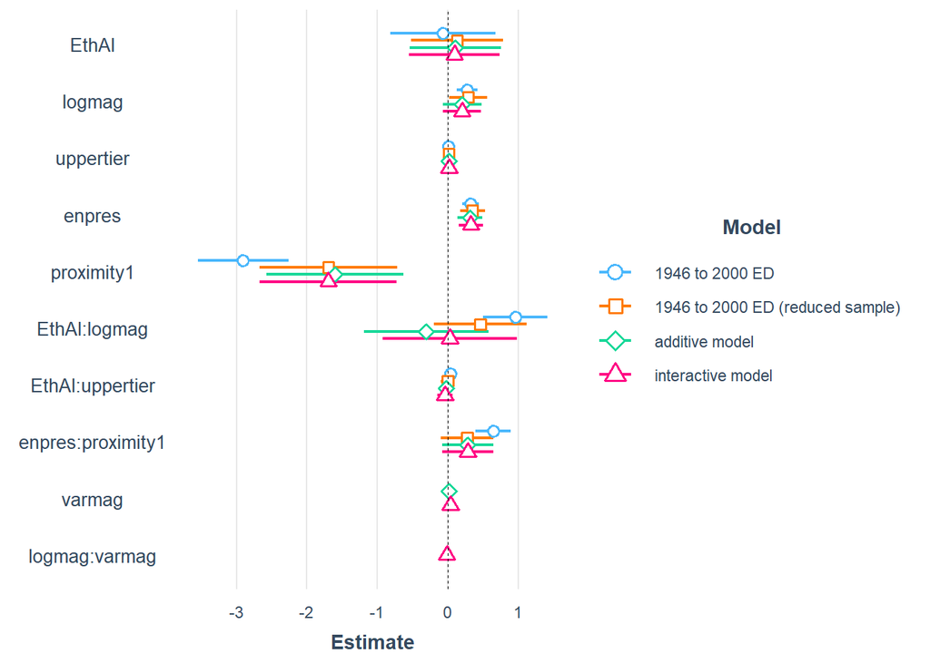

Some observations:

- Increasing R<sup>2</sup> , both adjusted and not.
- Significance for interactions is not relevant, we should plot the expected marginal effect (in the next section).

### Leverage Plots (partial effects)

Allow to see which cases are more influential for each variable in each model.

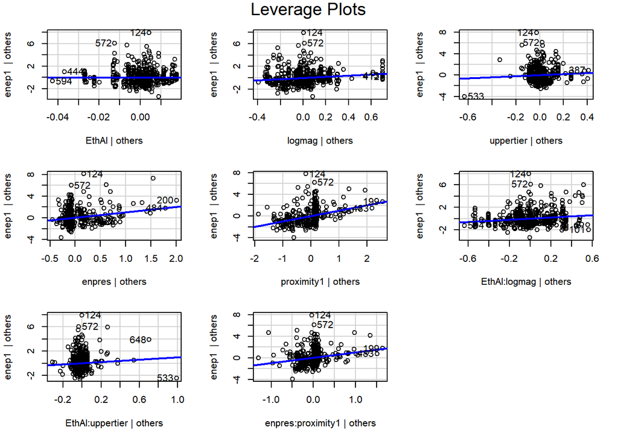

```r
EDAL <- lm(enep1~EthAl+logmag+uppertier+enpres+proximity1+logmag*EthAl+uppertier*EthAl+proximity1*enpres, data=subset(data, old==1))

EDAL1 <- lm(enep1~EthAl+logmag+uppertier+enpres+proximity1+logmag*EthAl+uppertier*EthAl+proximity1*enpres, data=subset(data, old==1&!is.na(data$varmag)))

EDALv <- lm(enep1~EthAl+logmag+uppertier+enpres+proximity1+logmag*EthAl+uppertier*EthAl+proximity1*enpres+varmag, data=subset(data, old==1&!is.na(data$varmag)))

EDALvx <- lm(enep1~EthAl+logmag+uppertier+enpres+proximity1+logmag*EthAl+uppertier*EthAl+proximity1*enpres+varmag+varmag*logmag, data=subset(data, old==1&!is.na(data$varmag)))

EDALlogvx <- lm(enep1~EthAl+logmag+uppertier+enpres+proximity1+logmag*EthAl+uppertier*EthAl+proximity1*enpres+log1p(varmag)+log1p(varmag)*logmag, data=subset(data, old==1&!is.na(data$varmag)))

leveragePlots(EDAL)
```

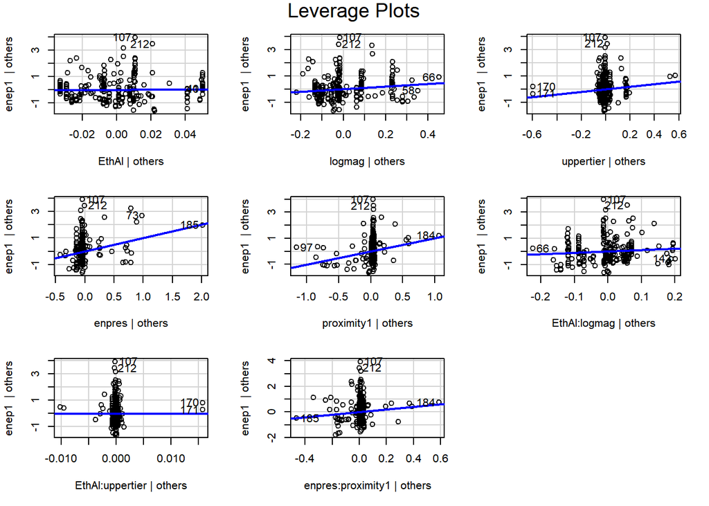

```r
leveragePlots(EDAL1)
```

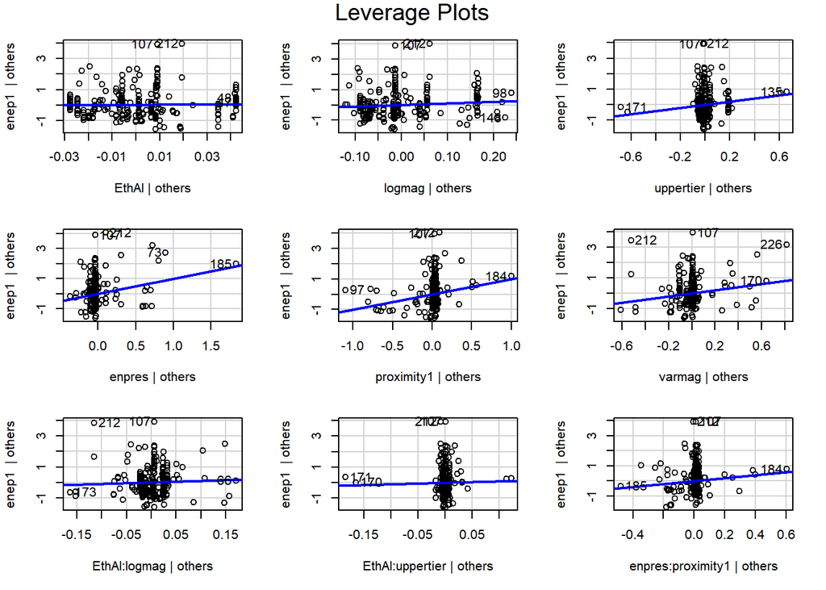

```r
leveragePlots(EDALv)
```

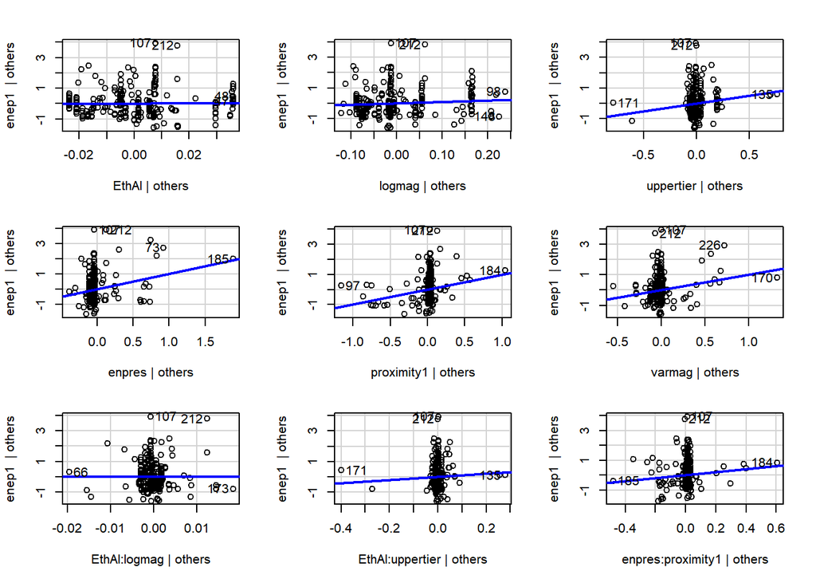

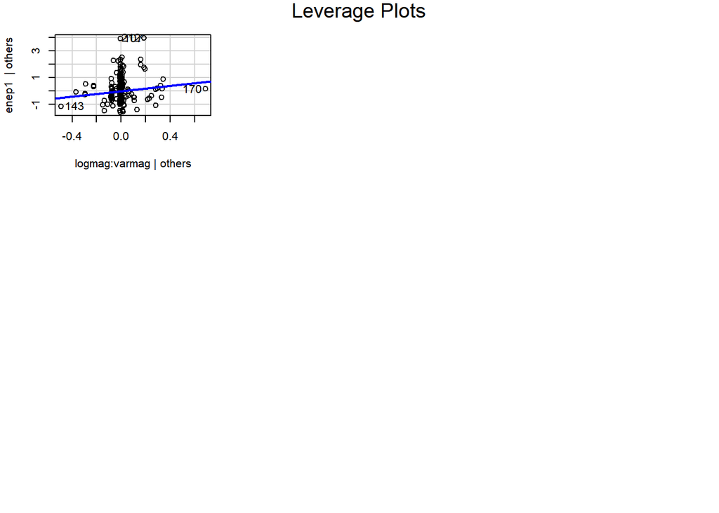

```r
leveragePlots(EDALvx)
```

### Interactions

This section adds interaction plots using “meplot”[^2].

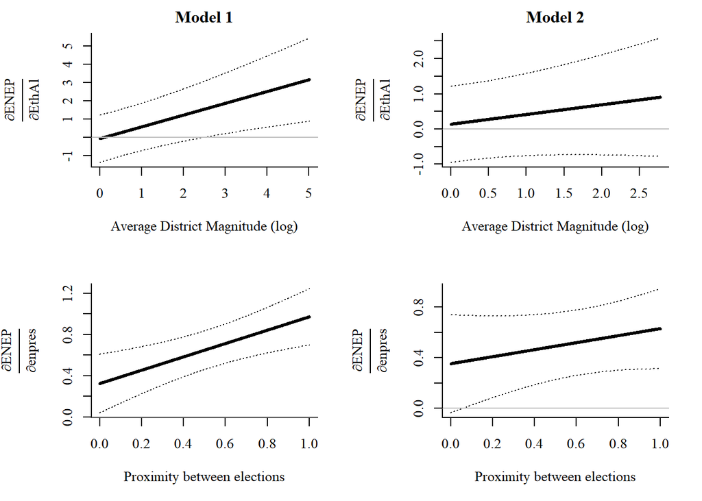

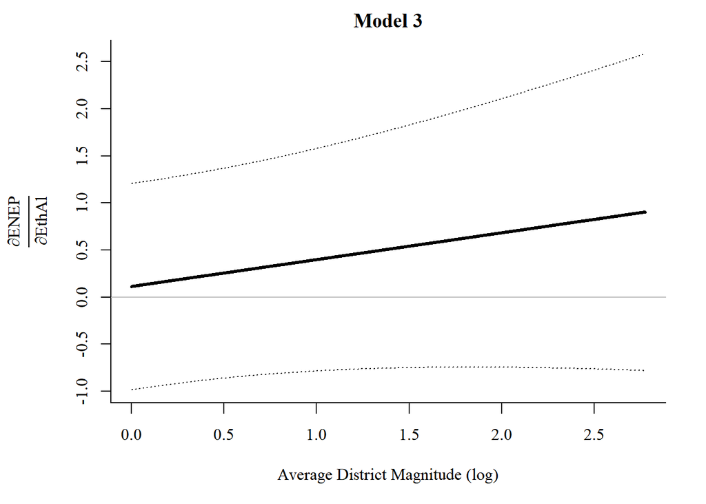

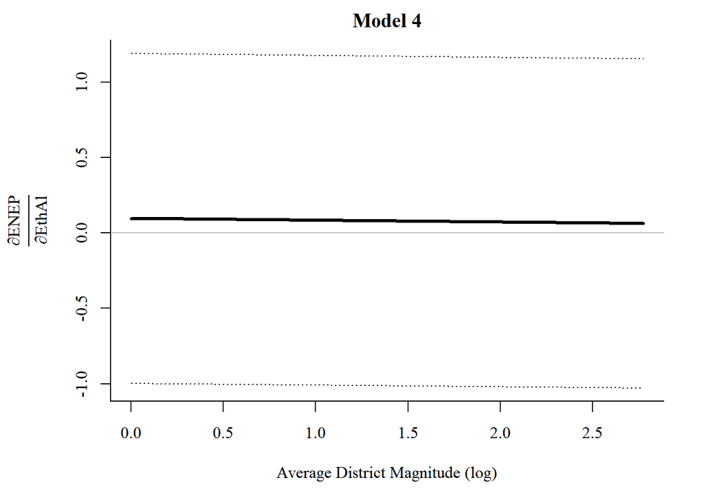

### Residual Plots

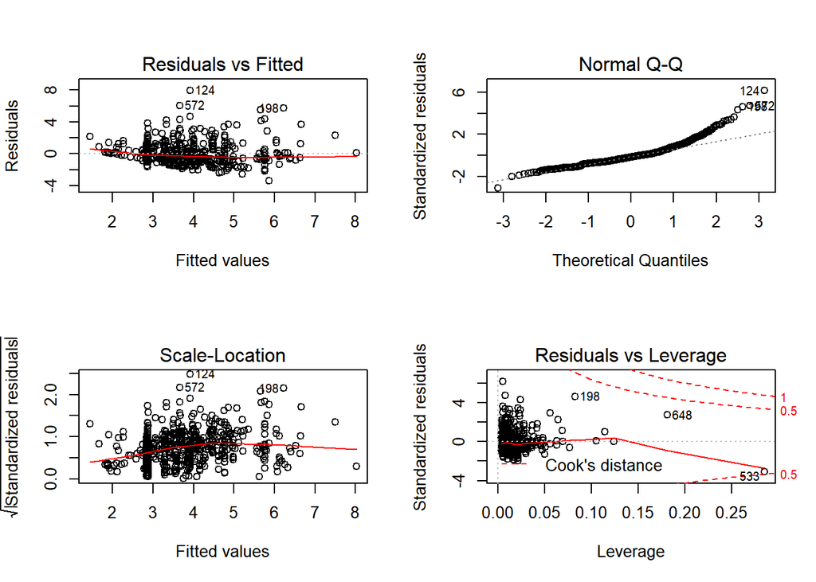

```r
par(mfrow=c(2,2))
plot(EDAL)
```

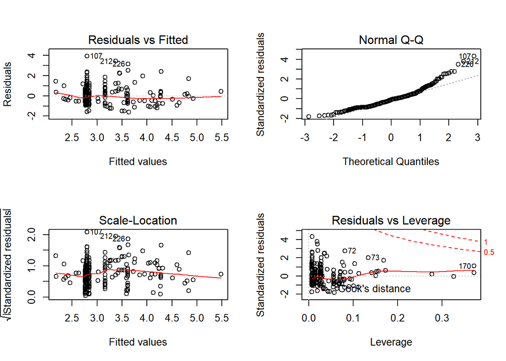

```r
plot(EDAL1)
```

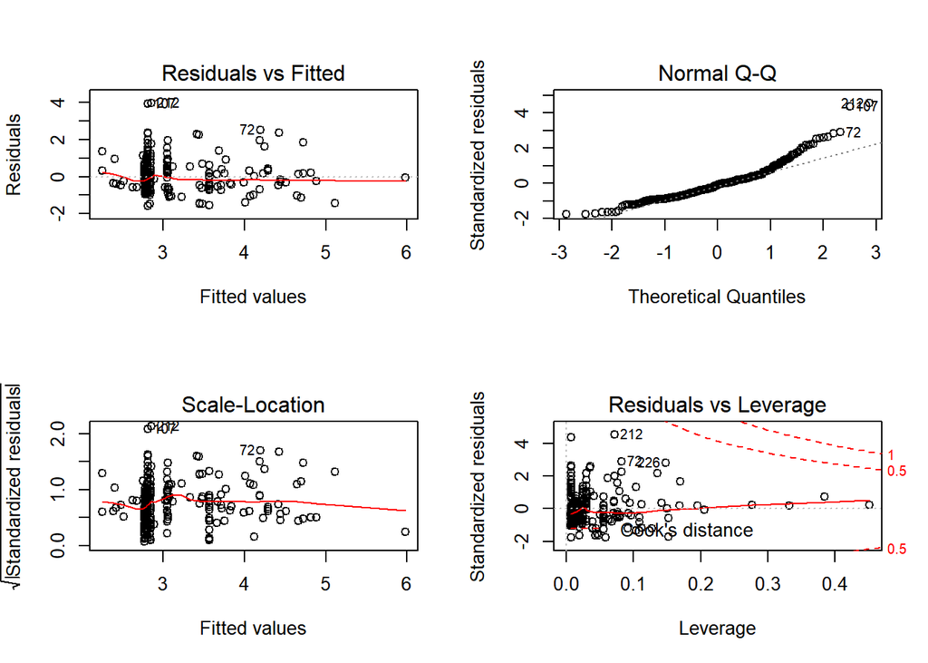

```r
plot(EDALv)
```

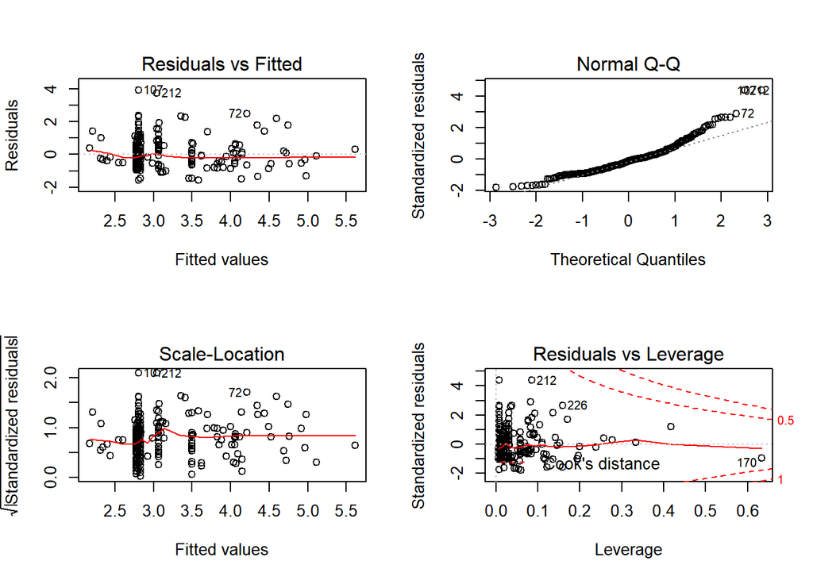

```r
plot(EDALvx)
```

### Cook’s distance

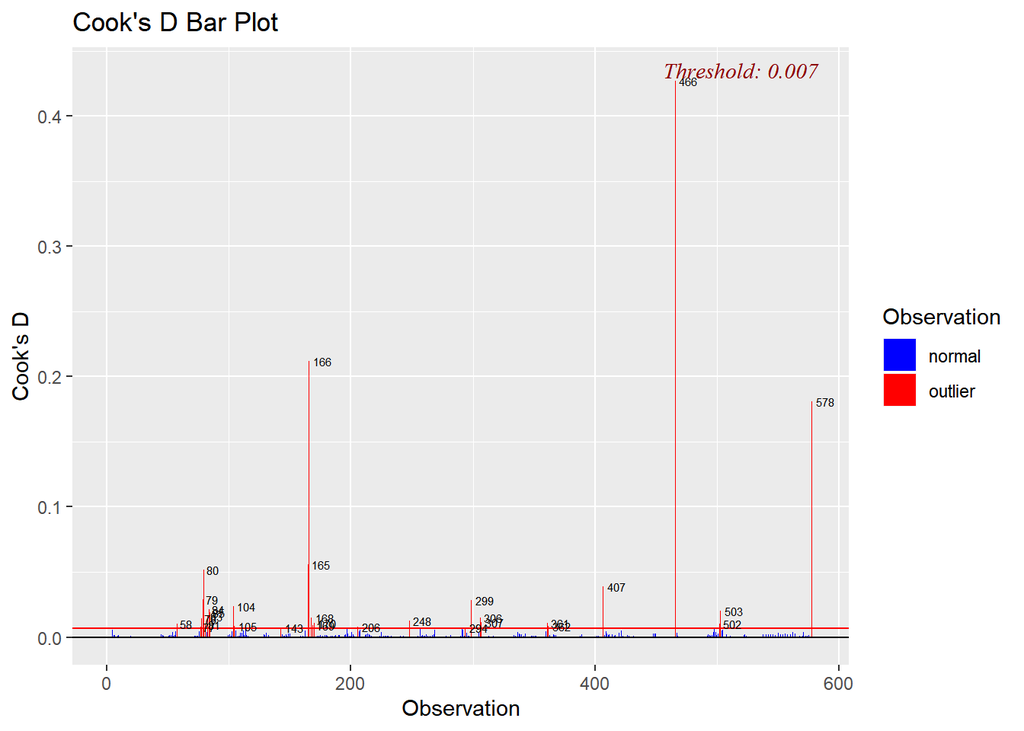

```r
ols_plot_cooksd_bar(EDAL)
```

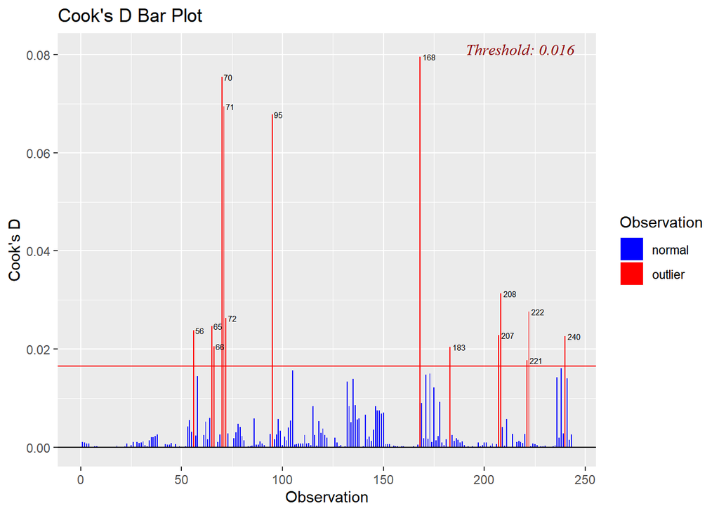

```r
ols_plot_cooksd_bar(EDAL1)
```

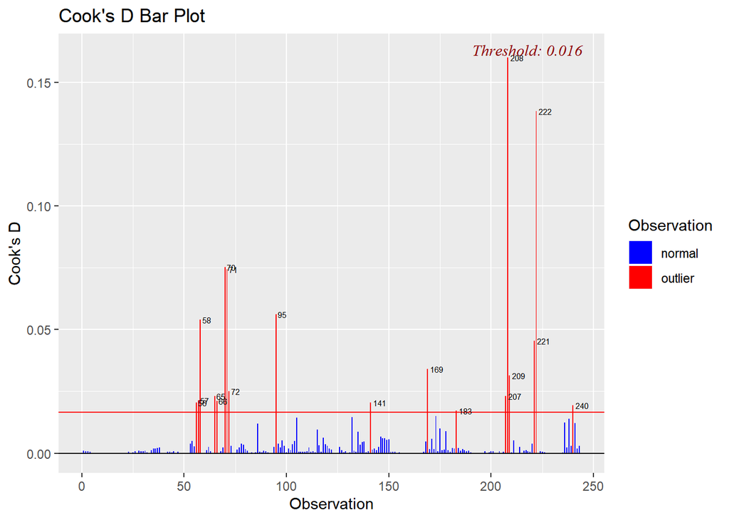

```r
ols_plot_cooksd_bar(EDALv)
```

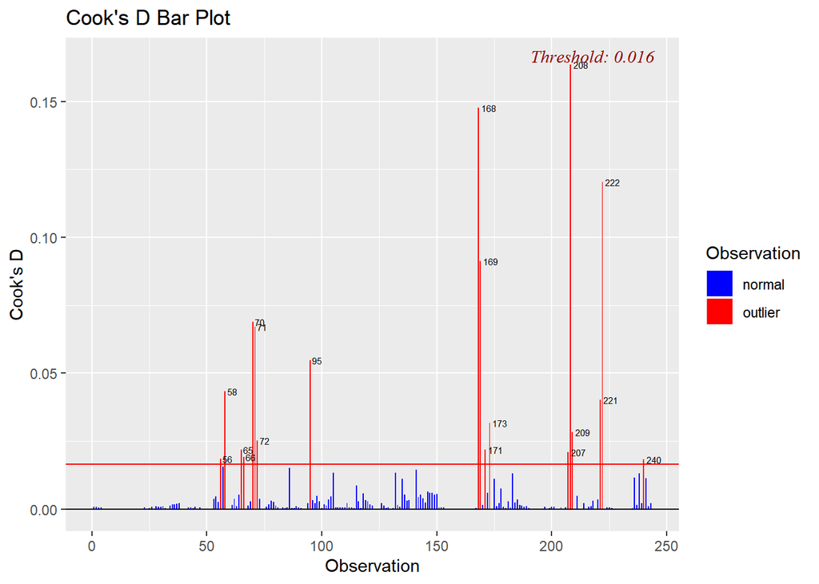

```r
ols_plot_cooksd_bar(EDALvx)
```

## Reproduce C&G2006 Marginal Effect Plot

```r
data <- read_dta("https://github.com/pgrau7/ES-0/blob/master/Creating%20the%20final%20dataset/LegisCLEAN.dta?raw=true")
```

Load meplot function (Williams, M.)[^3] and run it.

```r
library(plm)
library(sandwich)

CS1 <- lm(enep1~eneg+logmag+uppertier+enpres+proximity1+logmag*eneg+uppertier*eneg+proximity1*enpres, data=data)
robust_CS1 <- sqrt(diag(vcovPL(CS1, cluster = ~country+year, type="HC1")))

stargazer::stargazer(poolWS, CS1, dep.var.caption  = "plm vs. vcovPL manual",  column.labels = c("plm", "lm with vcovPL"), se=list(robust_seWS, robust_CS1), type="html")
```

|  | plm vs. vcovPL manual |  |
| --- | --- | --- |
|  | enep1 |  |
|  | *panel* | *OLS* |
|  | *linear* |  |
|  | plm | lm with vcovPL |
|  | (1) | (2) |
| eneg | 0.195 | 0.192* |
|  | (0.129) | (0.112) |
| logmag | 0.341* | 0.330** |
|  | (0.194) | (0.128) |
| uppertier | 0.049*** | 0.048*** |
|  | (0.015) | (0.005) |
| enpres | 0.348** | 0.345*** |
|  | (0.163) | (0.076) |
| proximity1 | -3.414*** | -3.418*** |
|  | (0.551) | (0.336) |
| eneg:logmag | 0.074 | 0.076 |
|  | (0.116) | (0.071) |
| eneg:uppertier | -0.016** | -0.016*** |
|  | (0.007) | (0.003) |
| enpres:proximity1 | 0.800*** | 0.800*** |
|  | (0.229) | (0.132) |
| Constant | 2.775*** | 2.811*** |
|  | (0.331) | (0.221) |
| Observations | 549 | 555 |
| R<sup>2</sup> | 0.305 | 0.299 |
| Adjusted R<sup>2</sup> | 0.295 | 0.289 |
| Residual Std. Error |  | 1.591 (df = 546) |
| F Statistic | 29.599*** (df = 8; 540) | 29.098*** (df = 8; 546) |
| *Note:* | p<0.1; p<0.05; p<0.01 |  |

# Marginal effect of interactive terms

## Replying Clark&Golder 2006

### Figure 1: The Marginal Effect of Ethnic Heterogeneity on the Effective Number of Electoral Parties

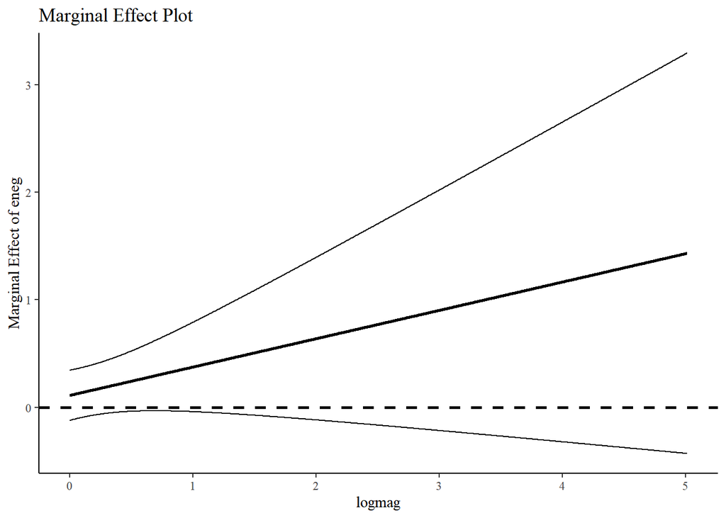

```r
library(sandwich)

# a) Pooled Analysis ??? Established Democracies

poolED <- plm(enep1~eneg+logmag+uppertier+enpres+proximity1+logmag*eneg+uppertier*eneg+proximity1*enpres, data=subset(data, old==1), index=c("country"), model="pooling")
robust_seED <- sqrt(diag(vcovHC(poolED, type = "HC1")))

meplot90(model=poolED,var1="eneg",var2="logmag", int="eneg:logmag", vcov = vcovHC.plm(poolED, type = "HC1"))
```

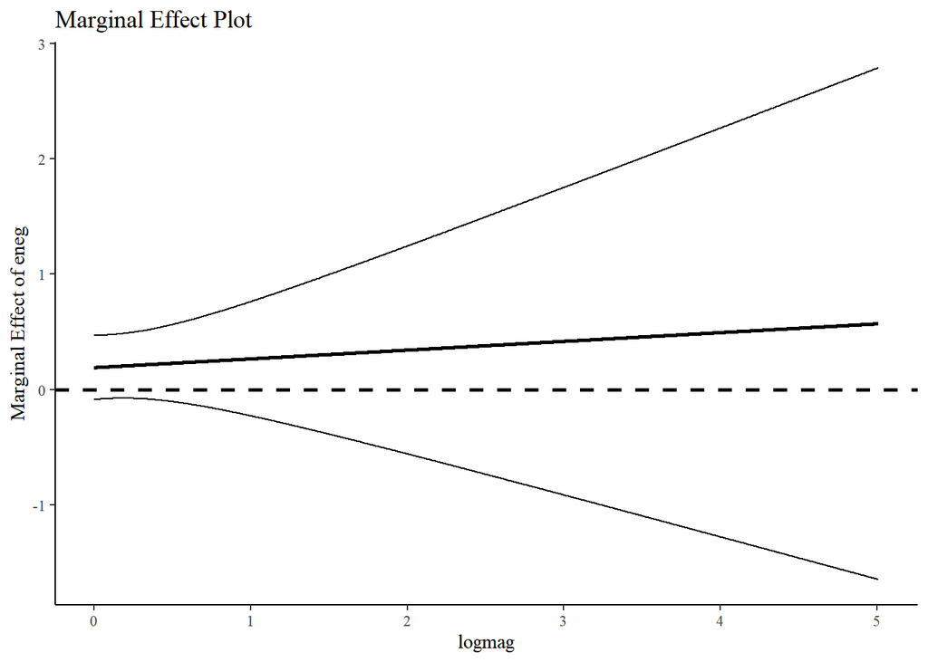

```r
meplot(model=CS1,var1="eneg",var2="logmag", int="eneg:logmag", vcov = vcovHC(poolED, type = "HC1"))
```

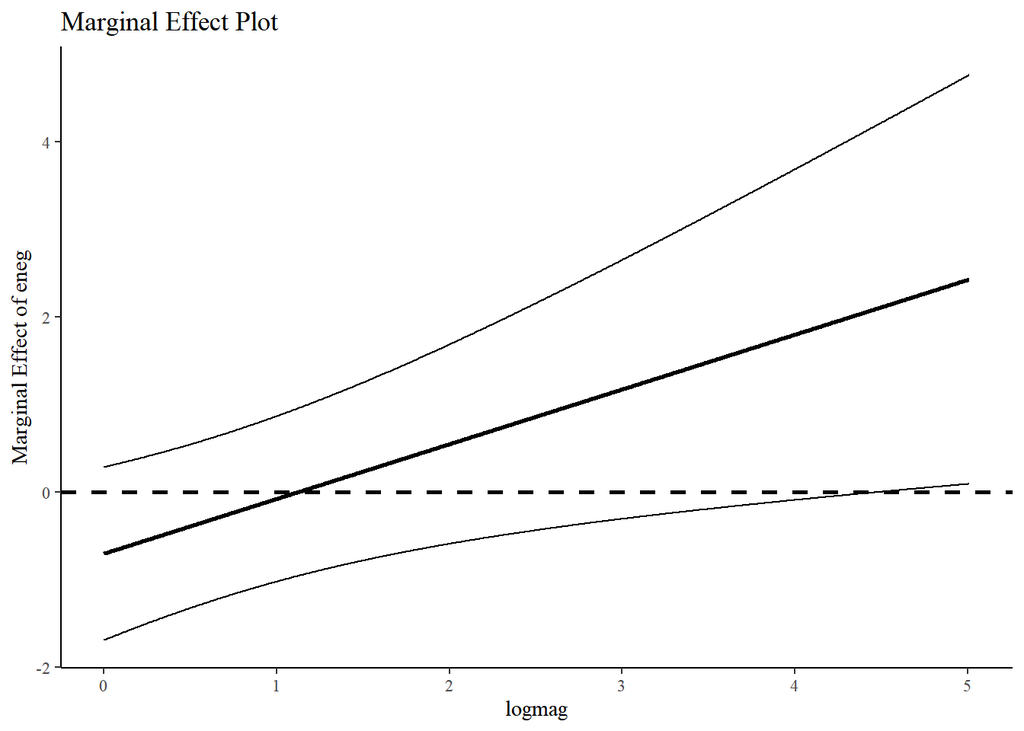

```r
#b) I don't have data for Neto&Cox

#c) 1990s ??? Established Democracies.
CS1 <- lm(enep1~eneg+logmag+uppertier+enpres+proximity1+logmag*eneg+uppertier*eneg+proximity1*enpres, data=subset(data, nineties==1&old==1))
robust_CS1 <- sqrt(diag(vcovHC(CS1, type = "HC1")))

meplot90(model=CS1,var1="eneg",var2="logmag", int="eneg:logmag", vcov = vcovHC(CS1, type = "HC"))
```

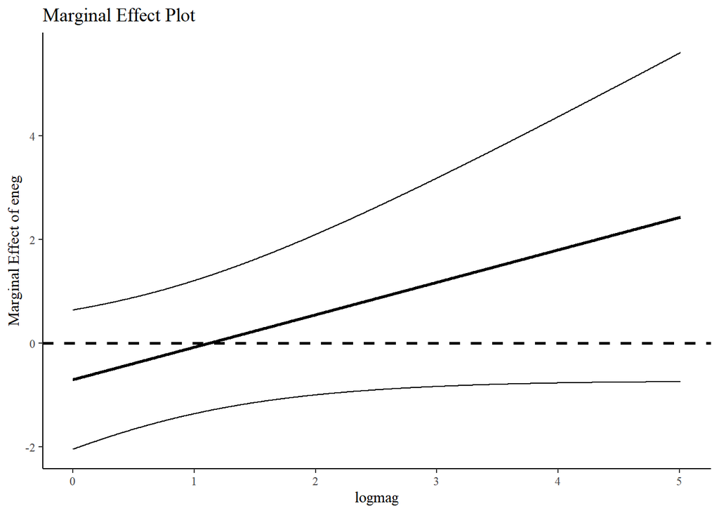

```r
meplot(model=CS1,var1="eneg",var2="logmag", int="eneg:logmag", vcov = vcovHC(CS1, type = "HC1"))
```

```r
##Conclusion: It doesn't seem to be exactly the same graph (even though the coefficients are the same). I think it must have to be related with the use of STATA or R. https://blog.theleapjournal.org/2016/06/sophisticated-clustered-standard-errors.html
```

It isn’t the same graph as CG2006, but the variance-covariance is it. The function seems correct.

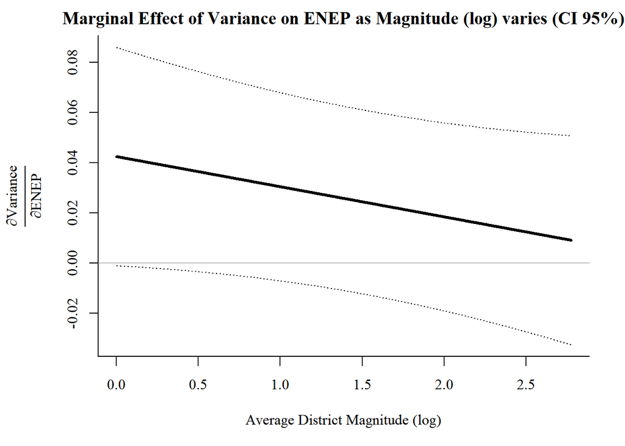

```r
par(family="serif",bty="l",mar=c(5,5.5,2,2))
meplotbasic(model=poolEDALvx,var1="varmag",var2="logmag",xlab = "Average District Magnitude (log)", ci=.95,
     ylab = expression(frac(partialdiff*paste("Variance"),
                            partialdiff*paste("ENEP"))),
     main="Marginal Effect of Variance on ENEP as Magnitude (log) varies (CI 95%)",
     ci_lty=3,yint_lty=1,yint_col="grey")
```

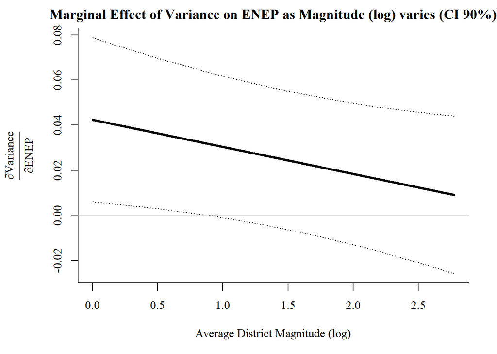

```r
par(family="serif",bty="l",mar=c(5,5.5,2,2))
meplotbasic(model=poolEDALvx,var1="varmag",var2="logmag",xlab = "Average District Magnitude (log)", ci=.90,
     ylab = expression(frac(partialdiff*paste("Variance"),
                            partialdiff*paste("ENEP"))),
     main="Marginal Effect of Variance on ENEP as Magnitude (log) varies (CI 90%)",
     ci_lty=3,yint_lty=1,yint_col="grey")
```

[^1]: Alesina, A., & Ferrara, E. La. (2005). Ethnic Diversity and Economic Performance. Journal of Economic Literature (Vol. XLIII).
[^2]: Williams, M.D. (n.d.) “Plotting marginal effects”, https://rpubs.com/milesdwilliams15/326345
[^3]: https://rstudio-pubs-static.s3.amazonaws.com/381372_361cdae2b43f4365aeee13a2663b1dee.html